# Covid-19 excess mortality in Latvia 2020

AAvj

Importation of necessary libraries.

If any is not installed it can be done with install.packages(“name”,dependencies=TRUE). Package name must be in quotes.

```r
suppressPackageStartupMessages(library(here))
suppressPackageStartupMessages(library(tidyverse)) # data processing
suppressPackageStartupMessages(library(mgcv)) # GAMs
suppressPackageStartupMessages(library(MuMIn)) # AICc
suppressPackageStartupMessages(library(haven)) # SPSS file import
suppressPackageStartupMessages(library(readxl)) # Excel file import
suppressPackageStartupMessages(library(car)) # model evaluation
suppressPackageStartupMessages(library(lubridate)) # dealing with dates
suppressPackageStartupMessages(library(patchwork)) # vizualisations
```

## Data

### Mortality data

Data are already partially processed in software SPSS, preparing death cause classes for analysis

Addition of the week of the year is necessary.

```r
mirusie <- read_sav("../dati/mirusie_2015_2020_newclasses.sav") # importing file from a location on my computer

mirusie$WOY=week(mirusie$mirsanas_datums) # adding the week of the year
```

Data contain casewise information - one line is one case

For ease of work, one variable with grouped causes is created

```r
mirusie$diagnozes=ifelse(mirusie$C00_C97==1,"Malignant_neoplasms",
                         ifelse(mirusie$E10_E14==1,"Diabetes_mellitus",
                                ifelse(mirusie$U07==1,"Covid_caused",
                                       ifelse(mirusie$J40_J47==1,"CLRd",
                                              ifelse(mirusie$V01_V99==1,"Traffic",
                                                     ifelse(mirusie$Circulatory_diseases==1,"Circulatory","Other"))))))
```

To run analysis count of cases per diagnosis in every week must be calculated. If there are no deaths, value 0 is imputed.

```r
diagnozes <- mirusie %>% # table diagnozes is created
  group_by(gads,WOY,diagnozes) %>% # calculus seperately for every diagnosis of every week in every year
  summarise(skaits=n()) %>% # calculus for the number of cases
  ungroup() %>% # data table is ungrouoped into single virtual file
  pivot_wider(names_from = diagnozes,values_from = skaits, values_fill = 0) %>% # that is spread for every diagnosis group
  # showing number of cases per week of every year
  group_by(gads,WOY) %>% # again grouped for week in year
  mutate(kopa=Circulatory+CLRd+Diabetes_mellitus+Malignant_neoplasms+Other+Traffic+Covid_caused) %>% # to calculate total number of cases
  ungroup() # and ungrouped into single virtual file
```

Additionally, table with the number of cases with Covid-19 as additional cause of death is created, following previous procedure

```r
diag_papild <- mirusie %>%
  mutate(papildus=ifelse(Covid_papildcēloņos=="Jā",1,0)) %>%
  group_by(gads,WOY,diagnozes) %>%
  summarise(skaits=sum(papildus,na.rm=TRUE)) %>%
  ungroup() %>%
  pivot_wider(names_from = diagnozes,values_from = skaits, values_fill = 0) %>%
  group_by(gads,WOY) %>%
  mutate(Covid_attributed=Circulatory+CLRd+Diabetes_mellitus+Malignant_neoplasms+Other+Traffic) %>%
  ungroup()
```

Preparation of data table with all the information of Covid-19 and deaths and arrange database by year and week of the year

```r
diag_papild <- diag_papild %>% select(gads,WOY,Covid_attributed) # select info on the number of Covid-attributed deaths

diagnozes <- merge(diagnozes,diag_papild,by=c("gads","WOY")) # combine both diagnosis data frames in one

diagnozes <- diagnozes %>%
  mutate(Covid_related = Covid_caused + Covid_attributed) %>%
  arrange(gads,WOY)
```

### Population

Weekly populations are calculated separately and available as Excel file. This file contains unnecessary information at the end of it, therefore during import, only first 54 rows are read.

```r
populacija <- read_excel("../dati/populacija.xlsx",n_max = 54) # location on my computer
str(populacija)
```

```
## tibble [53 x 7] (S3: tbl_df/tbl/data.frame)
##  $ nedela: num [1:53] 1 2 3 4 5 6 7 8 9 10 ...
##  $ 2015  : num [1:53] 1986 1986 1985 1985 1984 ...
##  $ 2016  : num [1:53] 1969 1968 1968 1967 1967 ...
##  $ 2017  : num [1:53] 1950 1950 1949 1949 1948 ...
##  $ 2018  : num [1:53] 1934 1934 1934 1933 1933 ...
##  $ 2019  : num [1:53] 1920 1920 1919 1919 1919 ...
##  $ 2020  : num [1:53] 1908 1907 1907 1907 1906 ...
```

Population is calculated in thousands and contains information per week in rows at year in columns. This must be converted to long format with individual row per week in year.

```r
populacija2 <- populacija %>%
  pivot_longer(cols=2:7,names_to="gads",values_to="pop")
```

Then population is converted to individuals and year to number from a character

```r
populacija2$pop=populacija2$pop*1000
populacija2$gads=as.numeric(populacija2$gads)
```

An unnecessary original file is removed from memory

```r
rm(populacija)
```

### Merging data

For analysis we need to merge these files containing population and the number of cases

```r
dati=merge(diagnozes,populacija2,by.x=c("gads","WOY"),by.y=c("gads","nedela"))
```

Arrange database by year and week of the year

```r
dati <- dati %>%
  arrange(gads,WOY)
```

We only need first 52 weeks of every year

```r
dati <- dati %>% filter(WOY<=52)
```

and it is better to have year as factor

```r
dati$fgads=as.factor(dati$gads)
```

# Models

Response - number of death cases

As population has changed, need to account for its size - *offset(log(pop))*

We care about weekly mortality and it`s change between years. It can be done with main effects model with regressors as follows:

- year as factor;
- week as numeric.

As there are 52 weeks, we are going to use 52 basis functions, that can be compared from fixed to model selected number.

We are going to compare between following basis functions:

- thin plate splines;
- cubic regression;
- cyclic cubic.

Models will be compared with AICc. The lower the AICc, the better is the generalization provided by the model.

All models will be fitted with Poisson family and log link function.

# Baseline length

We carried out baseline length evaluation only for All-cause mortality, comparing the effects of the year in above mentioned basis function and knot combinations.

Models and their speciffic data:

```r
bl1_data=dati %>% filter(!(gads==2020&WOY>=10))
bl1_tp_f=gam(kopa ~ fgads + s(WOY,k=52,fx=TRUE,bs="tp")+offset(log(pop)),data=bl1_data,family=poisson(link="log"),method="REML")
bl1_tp_s=gam(kopa ~ fgads + s(WOY,k=52,bs="tp")+offset(log(pop)),data=bl1_data,family=poisson(link="log"),method="REML")
bl1_cr_f=gam(kopa ~ fgads + s(WOY,k=52,fx=TRUE,bs="cr")+offset(log(pop)),data=bl1_data,family=poisson(link="log"),method="REML")
bl1_cr_s=gam(kopa ~ fgads + s(WOY,k=52,bs="cr")+offset(log(pop)),data=bl1_data,family=poisson(link="log"),method="REML")
bl1_cc_f=gam(kopa ~ fgads + s(WOY,k=52,fx=TRUE,bs="cc")+offset(log(pop)),data=bl1_data,family=poisson(link="log"),method="REML")
bl1_cc_s=gam(kopa ~ fgads + s(WOY,k=52,bs="cc")+offset(log(pop)),data=bl1_data,family=poisson(link="log"),method="REML")

bl2_data=dati %>% filter(!(gads==2020&WOY>=12))
bl2_tp_f=gam(kopa ~ fgads + s(WOY,k=52,fx=TRUE,bs="tp")+offset(log(pop)),data=bl2_data,family=poisson(link="log"),method="REML")
bl2_tp_s=gam(kopa ~ fgads + s(WOY,k=52,bs="tp")+offset(log(pop)),data=bl2_data,family=poisson(link="log"),method="REML")
bl2_cr_f=gam(kopa ~ fgads + s(WOY,k=52,fx=TRUE,bs="cr")+offset(log(pop)),data=bl2_data,family=poisson(link="log"),method="REML")
bl2_cr_s=gam(kopa ~ fgads + s(WOY,k=52,bs="cr")+offset(log(pop)),data=bl2_data,family=poisson(link="log"),method="REML")
bl2_cc_f=gam(kopa ~ fgads + s(WOY,k=52,fx=TRUE,bs="cc")+offset(log(pop)),data=bl2_data,family=poisson(link="log"),method="REML")
bl2_cc_s=gam(kopa ~ fgads + s(WOY,k=52,bs="cc")+offset(log(pop)),data=bl2_data,family=poisson(link="log"),method="REML")

bl3_data=dati %>% filter(!(gads==2020&WOY>=13))
bl3_tp_f=gam(kopa ~ fgads + s(WOY,k=52,fx=TRUE,bs="tp")+offset(log(pop)),data=bl3_data,family=poisson(link="log"),method="REML")
bl3_tp_s=gam(kopa ~ fgads + s(WOY,k=52,bs="tp")+offset(log(pop)),data=bl3_data,family=poisson(link="log"),method="REML")
bl3_cr_f=gam(kopa ~ fgads + s(WOY,k=52,fx=TRUE,bs="cr")+offset(log(pop)),data=bl3_data,family=poisson(link="log"),method="REML")
bl3_cr_s=gam(kopa ~ fgads + s(WOY,k=52,bs="cr")+offset(log(pop)),data=bl3_data,family=poisson(link="log"),method="REML")
bl3_cc_f=gam(kopa ~ fgads + s(WOY,k=52,fx=TRUE,bs="cc")+offset(log(pop)),data=bl3_data,family=poisson(link="log"),method="REML")
bl3_cc_s=gam(kopa ~ fgads + s(WOY,k=52,bs="cc")+offset(log(pop)),data=bl3_data,family=poisson(link="log"),method="REML")

bl4_data=dati %>% filter(!(gads==2020&WOY>=14))
bl4_tp_f=gam(kopa ~ fgads + s(WOY,k=52,fx=TRUE,bs="tp")+offset(log(pop)),data=bl4_data,family=poisson(link="log"),method="REML")
bl4_tp_s=gam(kopa ~ fgads + s(WOY,k=52,bs="tp")+offset(log(pop)),data=bl4_data,family=poisson(link="log"),method="REML")
bl4_cr_f=gam(kopa ~ fgads + s(WOY,k=52,fx=TRUE,bs="cr")+offset(log(pop)),data=bl4_data,family=poisson(link="log"),method="REML")
bl4_cr_s=gam(kopa ~ fgads + s(WOY,k=52,bs="cr")+offset(log(pop)),data=bl4_data,family=poisson(link="log"),method="REML")
bl4_cc_f=gam(kopa ~ fgads + s(WOY,k=52,fx=TRUE,bs="cc")+offset(log(pop)),data=bl4_data,family=poisson(link="log"),method="REML")
bl4_cc_s=gam(kopa ~ fgads + s(WOY,k=52,bs="cc")+offset(log(pop)),data=bl4_data,family=poisson(link="log"),method="REML")
```

Baseline lengths were compared for the effect in 2020 (relative risk compared to reference in 2015).

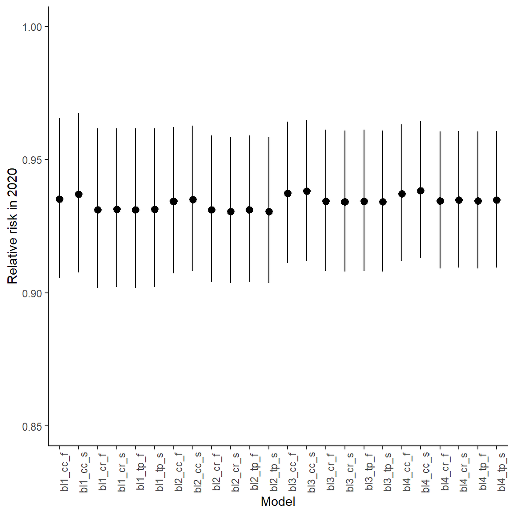

```r
modeli=c("bl1_tp_f","bl1_tp_s","bl1_cr_f","bl1_cr_s","bl1_cc_f","bl1_cc_s",
         "bl2_tp_f","bl2_tp_s","bl2_cr_f","bl2_cr_s","bl2_cc_f","bl2_cc_s",
         "bl3_tp_f","bl3_tp_s","bl3_cr_f","bl3_cr_s","bl3_cc_f","bl3_cc_s",
         "bl4_tp_f","bl4_tp_s","bl4_cr_f","bl4_cr_s","bl4_cc_f","bl4_cc_s")


funkcijai=function(mod){
  list(
  exp(summary(mod)$p.coeff[6]),
  exp(summary(mod)$p.coeff[6]-1.96*summary(mod)$se[6]),
  exp(summary(mod)$p.coeff[6]+1.96*summary(mod)$se[6])
  )
}

salidzinat=data.frame(modelis=modeli,
                      RR=rep(NA,length(modeli)),minRR=rep(NA,length(modeli)),maxRR=rep(NA,length(modeli)))

for (i in seq_along(modeli)){
  salidzinat[i,2]=funkcijai(get(modeli[i]))[1]
  salidzinat[i,3]=funkcijai(get(modeli[i]))[2]
  salidzinat[i,4]=funkcijai(get(modeli[i]))[3]
}


ggplot(salidzinat,aes(modelis,RR,ymin=minRR,ymax=maxRR))+theme_classic()+
  geom_point()+
  geom_pointrange()+
  coord_cartesian(ylim=c(0.85,1.0))+
  ylab("Relative risk in 2020")+
  xlab("Model")+
  theme(axis.text.x = element_text(angle=90))
```

All models provide considerably the same effect of 2020. Therefore, the best explainable baseline is to be used further on in an analysis. As our goal is to investigate effect on mortality we choose to use fourth baseline version - until the first confirmed death case.

# Training period

Model will be trained with data from the first week of 2015 until 13th (including) week of 2020.

```r
macibam <- dati %>%
  filter(!(gads==2020&WOY>=14))
```

The best model will be fitted to all dataset

# All cause mortality

Fitting models

```r
total_tp_c=gam(kopa ~ fgads + s(WOY,k=52,bs="tp")+offset(log(pop)),
               data=macibam,family=poisson(link="log"),method="REML")
total_tp_fx=gam(kopa ~ fgads + s(WOY,k=52,fx=TRUE,bs="tp")+offset(log(pop)),
                data=macibam,family=poisson(link="log"),method="REML")
total_cr_c=gam(kopa ~ fgads + s(WOY,k=51,bs="cr")+offset(log(pop)),
               data=macibam,family=poisson(link="log"),method="REML")
total_cr_fx=gam(kopa ~ fgads + s(WOY,k=52,fx=TRUE,bs="cr")+offset(log(pop)),
                data=macibam,family=poisson(link="log"),method="REML")
total_cc_c=gam(kopa ~ fgads + s(WOY,k=52,bs="cc")+offset(log(pop)),
               data=macibam,family=poisson(link="log"),method="REML")
total_cc_fx=gam(kopa ~ fgads + s(WOY,k=52,fx=TRUE,bs="cc")+offset(log(pop)),
                data=macibam,family=poisson(link="log"),method="REML")
```

Comparing fitted models. The best model is total_tp_c - thin plate splines with non-fixed effect of the week

```r
AICc(total_tp_c,total_tp_fx,total_cr_c,total_cr_fx,total_cc_c,total_cc_fx)
```

```
##                   df     AICc
## total_tp_c  18.91348 2720.878
## total_tp_fx 57.00000 2776.248
## total_cr_c  18.90832 2721.033
## total_cr_fx 57.00000 2776.248
## total_cc_c  19.88632 2727.096
## total_cc_fx 56.00000 2781.439
```

Model summary

```r
summary(total_tp_c)
```

```
##
## Family: poisson
## Link function: log
##
## Formula:
## kopa ~ fgads + s(WOY, k = 52, bs = "tp") + offset(log(pop))
##
## Parametric coefficients:
##              Estimate Std. Error   z value Pr(>|z|)
## (Intercept) -8.203199   0.005967 -1374.714  < 2e-16 ***
## fgads2016    0.008396   0.008439     0.995 0.319824
## fgads2017    0.028818   0.008416     3.424 0.000617 ***
## fgads2018    0.039180   0.008410     4.659 3.18e-06 ***
## fgads2019    0.008368   0.008490     0.986 0.324333
## fgads2020   -0.067437   0.013943    -4.837 1.32e-06 ***
## ---
## Signif. codes:  0 '***' 0.001 '**' 0.01 '*' 0.05 '.' 0.1 ' ' 1
##
## Approximate significance of smooth terms:
##          edf Ref.df Chi.sq p-value
## s(WOY) 11.96  14.94  905.8  <2e-16 ***
## ---
## Signif. codes:  0 '***' 0.001 '**' 0.01 '*' 0.05 '.' 0.1 ' ' 1
##
## R-sq.(adj) =  0.654   Deviance explained = 67.2%
## -REML = 1392.2  Scale est. = 1         n = 273
```

Relative risks for years

```r
apk_total_tp_c=summary(total_tp_c)
RR_total=round(exp(apk_total_tp_c$p.coeff),3)
RRmin_total=round(exp(apk_total_tp_c$p.coeff-1.96*apk_total_tp_c$se[1:6]),3)
RRmax_total=round(exp(apk_total_tp_c$p.coeff+1.96*apk_total_tp_c$se[1:6]),3)
rbind(RR_total,RRmin_total,RRmax_total)
```

```
##             (Intercept) fgads2016 fgads2017 fgads2018 fgads2019 fgads2020
## RR_total              0     1.008     1.029     1.040     1.008     0.935
## RRmin_total           0     0.992     1.012     1.023     0.992     0.910
## RRmax_total           0     1.025     1.046     1.057     1.025     0.961
```

### Confidence intervals

Prediction of the numbers of cases with 95% confidence intervals.

```r
pred_total_tp_c=as.data.frame(predict(total_tp_c,newdata = dati,se=TRUE,type="response")) # prediction with standart error
pred_total_tp_c$min_total_tp_c=pred_total_tp_c$fit-1.96*pred_total_tp_c$se.fit # lower boundary is 1.96 standart errors below the mean
pred_total_tp_c$max_total_tp_c=pred_total_tp_c$fit+1.96*pred_total_tp_c$se.fit # lower boundary is 1.96 standart errors above the mean
colnames(pred_total_tp_c)[1]="fit_total_tp_c" # renaming columns
pred_total_tp_c=pred_total_tp_c[,c(1,3,4)] # selecting necessary columns

totalie=cbind(dati,pred_total_tp_c) # combining prediction with data
```

### Prediction intervals

Prediction intervals cannot be obtained with function predict as in lm. They have to be simulated from the posterior.

```r
# extract the parameter estimates and their covariance matrix
beta=coef(total_tp_c)
V=vcov(total_tp_c)

# Simulate number of parameter vectors by Cholesky factorisation of the covariance matrix
num_beta_vecs <- 10000
Cv <- chol(V)
set.seed(1)
nus <- rnorm(num_beta_vecs * length(beta))
beta_sims <- beta + t(Cv) %*% matrix(nus, nrow = length(beta), ncol = num_beta_vecs)


# use data for predictions
sim_dat2=dati

# calculate linear predictors
covar_sim <- predict(total_tp_c, newdata = sim_dat2, type = "lpmatrix")
linpred_sim <- covar_sim %*% beta_sims

# inverse link function
exp_val_sim <- exp(linpred_sim)

# matrix for predictions
exp_val_sim2 <- matrix(NA,nrow=nrow(exp_val_sim),ncol=ncol(exp_val_sim))

# as offset was used, need to account for population size
for (i in 1:ncol(exp_val_sim)){
  for (j in 1:nrow(exp_val_sim)){
    exp_val_sim2[j,i]=exp_val_sim[j,i]*dati$pop[j]
  }
}

# posterior draws from Poisson family
y_sim <- matrix(rpois(n = prod(dim(exp_val_sim2)),
                      lambda = exp_val_sim2),
                nrow = nrow(exp_val_sim2),
                ncol = ncol(exp_val_sim2))

# reduction to prediction interval
pred_int_sim <- apply(y_sim, 1, quantile, prob = c(.025, 0.975))

# transpose matrix
predint_total_tp_c=t(pred_int_sim)

# combine with data and confidence intervals
kopejais_total_tp_c=cbind(dati,pred_total_tp_c,predint_total_tp_c)
```

### Results

Preparation of table with observed, model predicted, difference and excess values

```r
# Extract values from 2020
total_2020=kopejais_total_tp_c %>%
  filter(fgads==2020)

# pick necessary columns
total_2020_csv=total_2020[,c("gads","WOY","pop","Covid_caused","Covid_attributed","Covid_related","kopa","fit_total_tp_c","2.5%","97.5%")]

# create table
total_2020_csv=total_2020_csv %>%
  mutate(AllCause_observed=kopa,
         AllCause_fitted=round(fit_total_tp_c,0),
         AllCause_PImin=round(`2.5%`,0),
         AllCause_PImax=round(`97.5%`,0)) %>%
  group_by(WOY,pop,Covid_caused,Covid_attributed,Covid_related,AllCause_observed,AllCause_fitted,AllCause_PImin,AllCause_PImax) %>%
  summarize(AllCause_diff=round(AllCause_observed-fit_total_tp_c,0),
            AllCause_diff_min=round(AllCause_observed-AllCause_PImax,0),
            AllCause_diff_max=round(AllCause_observed-AllCause_PImin,0),
            AllCause_excess=ifelse(round(AllCause_observed-fit_total_tp_c,0)>0,
                                   round(AllCause_observed-fit_total_tp_c,0),0),
            AllCause_excess_max=ifelse(round(AllCause_observed-AllCause_PImin,0)>0,
                                       round(AllCause_observed-AllCause_PImin,0),0),
            AllCause_excess_min=ifelse(round(AllCause_observed-AllCause_PImax,0)>0,
                                       round(AllCause_observed-AllCause_PImax,0),0)) %>%
  ungroup()
write_excel_csv2(total_2020_csv,"./outputs/table_AllCause.csv") # write resulting table to file
```

### Figures

Observed and model predicted values in 2020

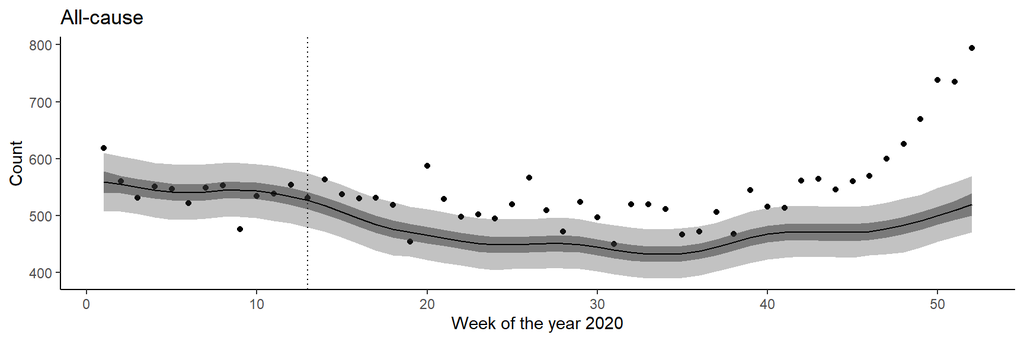

```r
attels_total_weeks <- ggplot(total_2020,aes(x=WOY,y=kopa))+
  geom_vline(xintercept=13,lty=3)+
  theme_classic()+
  geom_point()+
  geom_ribbon(data=total_2020,aes(x=WOY,ymin=`2.5%`,ymax=`97.5%`),alpha=.3)+
  geom_ribbon(data=total_2020,aes(x=WOY,ymin=min_total_tp_c,ymax=max_total_tp_c),alpha=.5)+
  geom_line(data=total_2020,aes(x=WOY,y=fit_total_tp_c))+
  xlab("Week of the year 2020")+
  ylab("Count")+
  ggtitle("All-cause")
attels_total_weeks
```

# I00_I99 - circular diseases

Circular disease models

```r
I00I99_tp_c=gam(Circulatory ~ fgads + s(WOY,k=52,bs="tp")+offset(log(pop)),
               data=macibam,family=poisson(link="log"),method="REML")
I00I99_tp_fx=gam(Circulatory ~ fgads + s(WOY,k=52,fx=TRUE,bs="tp")+offset(log(pop)),
                data=macibam,family=poisson(link="log"),method="REML")
I00I99_cr_c=gam(Circulatory ~ fgads + s(WOY,k=51,bs="cr")+offset(log(pop)),
               data=macibam,family=poisson(link="log"),method="REML")
I00I99_cr_fx=gam(Circulatory ~ fgads + s(WOY,k=52,fx=TRUE,bs="cr")+offset(log(pop)),
                data=macibam,family=poisson(link="log"),method="REML")
I00I99_cc_c=gam(Circulatory ~ fgads + s(WOY,k=52,bs="cc")+offset(log(pop)),
               data=macibam,family=poisson(link="log"),method="REML")
I00I99_cc_fx=gam(Circulatory ~ fgads + s(WOY,k=52,fx=TRUE,bs="cc")+offset(log(pop)),
                data=macibam,family=poisson(link="log"),method="REML")
```

Model selection. The best model is I00I99_tp_c - thin plate splines with non-fixed effect of the week

```r
AICc(I00I99_tp_c,I00I99_tp_fx,I00I99_cr_c,I00I99_cr_fx,I00I99_cc_c,I00I99_cc_fx)
```

```
##                    df     AICc
## I00I99_tp_c  18.07049 2449.404
## I00I99_tp_fx 57.00000 2516.841
## I00I99_cr_c  18.09045 2449.518
## I00I99_cr_fx 57.00000 2516.841
## I00I99_cc_c  19.24502 2454.485
## I00I99_cc_fx 56.00000 2518.504
```

Model summary

```r
summary(I00I99_tp_c)
```

```
##
## Family: poisson
## Link function: log
##
## Formula:
## Circulatory ~ fgads + s(WOY, k = 52, bs = "tp") + offset(log(pop))
##
## Parametric coefficients:
##              Estimate Std. Error   z value Pr(>|z|)
## (Intercept) -8.888881   0.008405 -1057.590  < 2e-16 ***
## fgads2016   -0.011806   0.011945    -0.988   0.3230
## fgads2017   -0.021677   0.012003    -1.806   0.0709 .
## fgads2018   -0.016969   0.012012    -1.413   0.1578
## fgads2019   -0.070370   0.012201    -5.768 8.04e-09 ***
## fgads2020   -0.129698   0.019880    -6.524 6.84e-11 ***
## ---
## Signif. codes:  0 '***' 0.001 '**' 0.01 '*' 0.05 '.' 0.1 ' ' 1
##
## Approximate significance of smooth terms:
##          edf Ref.df Chi.sq p-value
## s(WOY) 11.17  13.95  775.3  <2e-16 ***
## ---
## Signif. codes:  0 '***' 0.001 '**' 0.01 '*' 0.05 '.' 0.1 ' ' 1
##
## R-sq.(adj) =  0.674   Deviance explained =   68%
## -REML = 1253.1  Scale est. = 1         n = 273
```

Relative risks

```r
apk_I00I99_tp_c=summary(I00I99_tp_c)
RR_I00I99=round(exp(apk_I00I99_tp_c$p.coeff),3)
RRmin_I00I99=round(exp(apk_I00I99_tp_c$p.coeff-1.96*apk_I00I99_tp_c$se[1:6]),3)
RRmax_I00I99=round(exp(apk_I00I99_tp_c$p.coeff+1.96*apk_I00I99_tp_c$se[1:6]),3)
rbind(RR_I00I99,RRmin_I00I99,RRmax_I00I99)
```

```
##              (Intercept) fgads2016 fgads2017 fgads2018 fgads2019 fgads2020
## RR_I00I99              0     0.988     0.979     0.983     0.932     0.878
## RRmin_I00I99           0     0.965     0.956     0.960     0.910     0.845
## RRmax_I00I99           0     1.012     1.002     1.007     0.955     0.913
```

### Confidence intervals

Prediction of the numbers of cases with 95% confidence intervals.

```r
pred_I00I99_tp_c=as.data.frame(predict(I00I99_tp_c,newdata = dati,se=TRUE,type="response"))
pred_I00I99_tp_c$min_I00I99_tp_c=pred_I00I99_tp_c$fit-1.96*pred_I00I99_tp_c$se.fit
pred_I00I99_tp_c$max_I00I99_tp_c=pred_I00I99_tp_c$fit+1.96*pred_I00I99_tp_c$se.fit
colnames(pred_I00I99_tp_c)[1]="fit_I00I99_tp_c"
pred_I00I99_tp_c=pred_I00I99_tp_c[,c(1,3,4)]

I00I99ie=cbind(dati,pred_I00I99_tp_c)
```

### Prediction intervals

Prediction intervals cannot be obtained with function predict as in lm. They have to be simulated from the posterior.

```r
# extract the parameter estimates and their covariance matrix
beta=coef(I00I99_tp_c)
V=vcov(I00I99_tp_c)

# Simulate number of parameter vectors by Cholesky factorisation of the covariance matrix
num_beta_vecs <- 10000
Cv <- chol(V)
set.seed(1)
nus <- rnorm(num_beta_vecs * length(beta))
beta_sims <- beta + t(Cv) %*% matrix(nus, nrow = length(beta), ncol = num_beta_vecs)

# use data for predictions
sim_dat2=dati


# calculate linear predictors
covar_sim <- predict(I00I99_tp_c, newdata = sim_dat2, type = "lpmatrix")
linpred_sim <- covar_sim %*% beta_sims


# inverse link function
exp_val_sim <- exp(linpred_sim)


# matrix for predictions
exp_val_sim2 <- matrix(NA,nrow=nrow(exp_val_sim),ncol=ncol(exp_val_sim))


# as offset was used, need to account for population size
for (i in 1:ncol(exp_val_sim)){
  for (j in 1:nrow(exp_val_sim)){
    exp_val_sim2[j,i]=exp_val_sim[j,i]*dati$pop[j]
  }
}


# posterior draws from Poisson family
y_sim <- matrix(rpois(n = prod(dim(exp_val_sim2)),
                      lambda = exp_val_sim2),
                nrow = nrow(exp_val_sim2),
                ncol = ncol(exp_val_sim2))


# reduction to prediction interval
pred_int_sim <- apply(y_sim, 1, quantile, prob = c(.025, 0.975))


# transpose matrix
predint_I00I99_tp_c=t(pred_int_sim)


# combine with data and confidence intervals
kopejais_I00I99_tp_c=cbind(dati,pred_I00I99_tp_c,predint_I00I99_tp_c)
```

### Results

Preparation of table with observed, model predicted, difference and excess values

```r
# Extract values from 2020
I00I99_2020=kopejais_I00I99_tp_c %>%
  filter(fgads==2020)


# pick necessary columns
I00I99_2020_csv=I00I99_2020[,c("gads","WOY","pop","Circulatory","fit_I00I99_tp_c","2.5%","97.5%")]

# create table
I00I99_2020_csv=I00I99_2020_csv %>%
  mutate(Circulatory_observed=Circulatory,
         Circulatory_fitted=round(fit_I00I99_tp_c,0),
         Circulatory_PImin=round(`2.5%`,0),
         Circulatory_PImax=round(`97.5%`,0)) %>%
  group_by(WOY,Circulatory_observed,Circulatory_fitted,Circulatory_PImin,Circulatory_PImax) %>%
  summarize(Circulatory_diff=round(Circulatory_observed-Circulatory_fitted,0),
            Circulatory_diff_PImin=round(Circulatory_observed-Circulatory_PImax,0),
            Circulatory_diff_PImax=round(Circulatory_observed-Circulatory_PImin,0),
            Circulatory_excess=ifelse(round(Circulatory_observed-Circulatory_fitted,0)>0,
                                      round(Circulatory_observed-Circulatory_fitted,0),0),
            Circulatory_excess_PImin=ifelse(round(Circulatory_observed-Circulatory_PImax,0)>0,
                                            round(Circulatory_observed-Circulatory_PImax,0),0),
            Circulatory_excess_PImax=ifelse(round(Circulatory_observed-Circulatory_PImin,0)>0,
                                            round(Circulatory_observed-Circulatory_PImin,0),0)) %>%
ungroup()
write_excel_csv2(I00I99_2020_csv,"./outputs/table_Circulatory.csv") # write resulting table to file
```

### Figures

Observed and model predicted values in 2020

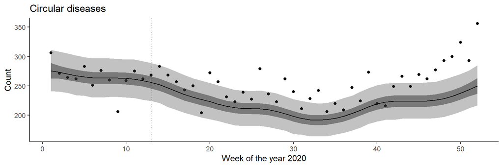

```r
attels_I00I99_weeks <- ggplot(I00I99_2020,aes(x=WOY,y=Circulatory))+
  geom_vline(xintercept=13,lty=3)+
  theme_classic()+
  geom_point()+
  geom_ribbon(data=I00I99_2020,aes(x=WOY,ymin=`2.5%`,ymax=`97.5%`),alpha=.3)+
  geom_ribbon(data=I00I99_2020,aes(x=WOY,ymin=min_I00I99_tp_c,ymax=max_I00I99_tp_c),alpha=.5)+
  geom_line(data=I00I99_2020,aes(x=WOY,y=fit_I00I99_tp_c))+
  xlab("Week of the year 2020")+
  ylab("Count")+
  ggtitle("Circular diseases")
attels_I00I99_weeks
```

# C00_C97 - oncology

Fitting models

```r
C00C97_tp_c=gam(Malignant_neoplasms ~ fgads + s(WOY,k=52,bs="tp")+offset(log(pop)),
               data=macibam,family=poisson(link="log"),method="REML")
C00C97_tp_fx=gam(Malignant_neoplasms ~ fgads + s(WOY,k=52,fx=TRUE,bs="tp")+offset(log(pop)),
                data=macibam,family=poisson(link="log"),method="REML")
C00C97_cr_c=gam(Malignant_neoplasms ~ fgads + s(WOY,k=51,bs="cr")+offset(log(pop)),
               data=macibam,family=poisson(link="log"),method="REML")
C00C97_cr_fx=gam(Malignant_neoplasms ~ fgads + s(WOY,k=52,fx=TRUE,bs="cr")+offset(log(pop)),
                data=macibam,family=poisson(link="log"),method="REML")
C00C97_cc_c=gam(Malignant_neoplasms ~ fgads + s(WOY,k=52,bs="cc")+offset(log(pop)),
               data=macibam,family=poisson(link="log"),method="REML")
C00C97_cc_fx=gam(Malignant_neoplasms ~ fgads + s(WOY,k=52,fx=TRUE,bs="cc")+offset(log(pop)),
                data=macibam,family=poisson(link="log"),method="REML")
```

Comparing fitted models. The best model is C00C97_cc_c - cyclic cubic splines with non-fixed effect of the week

```r
AICc(C00C97_tp_c,C00C97_tp_fx,C00C97_cr_c,C00C97_cr_fx,C00C97_cc_c,C00C97_cc_fx)
```

```
##                     df     AICc
## C00C97_tp_c   9.146804 2061.103
## C00C97_tp_fx 57.000000 2142.543
## C00C97_cr_c   9.221715 2061.265
## C00C97_cr_fx 57.000000 2142.543
## C00C97_cc_c   8.991588 2059.893
## C00C97_cc_fx 56.000000 2140.044
```

Model summary

```r
summary(C00C97_cc_c)
```

```
##
## Family: poisson
## Link function: log
##
## Formula:
## Malignant_neoplasms ~ fgads + s(WOY, k = 52, bs = "cc") + offset(log(pop))
##
## Parametric coefficients:
##             Estimate Std. Error  z value Pr(>|z|)
## (Intercept) -9.77313    0.01307 -747.543   <2e-16 ***
## fgads2016    0.01225    0.01847    0.663   0.5073
## fgads2017    0.03915    0.01839    2.129   0.0333 *
## fgads2018    0.03728    0.01843    2.023   0.0431 *
## fgads2019    0.04290    0.01844    2.327   0.0200 *
## fgads2020    0.02475    0.02997    0.826   0.4089
## ---
## Signif. codes:  0 '***' 0.001 '**' 0.01 '*' 0.05 '.' 0.1 ' ' 1
##
## Approximate significance of smooth terms:
##          edf Ref.df Chi.sq p-value
## s(WOY) 2.375     50  11.72 0.00147 **
## ---
## Signif. codes:  0 '***' 0.001 '**' 0.01 '*' 0.05 '.' 0.1 ' ' 1
##
## R-sq.(adj) =  0.0361   Deviance explained = 8.53%
## -REML = 1043.9  Scale est. = 1         n = 273
```

Relative risks for years

```r
apk_C00C97_cc_c=summary(C00C97_cc_c)
RR_C00C97=round(exp(apk_C00C97_cc_c$p.coeff),3)
RRmin_C00C97=round(exp(apk_C00C97_cc_c$p.coeff-1.96*apk_C00C97_cc_c$se[1:6]),3)
RRmax_C00C97=round(exp(apk_C00C97_cc_c$p.coeff+1.96*apk_C00C97_cc_c$se[1:6]),3)
rbind(RR_C00C97,RRmin_C00C97,RRmax_C00C97)
```

```
##              (Intercept) fgads2016 fgads2017 fgads2018 fgads2019 fgads2020
## RR_C00C97              0     1.012     1.040     1.038     1.044     1.025
## RRmin_C00C97           0     0.976     1.003     1.001     1.007     0.967
## RRmax_C00C97           0     1.050     1.078     1.076     1.082     1.087
```

### Confidence intervals

Prediction of the numbers of cases with 95% confidence intervals.

```r
pred_C00C97_cc_c=as.data.frame(predict(C00C97_cc_c,newdata = dati,se=TRUE,type="response"))
pred_C00C97_cc_c$min_C00C97_cc_c=pred_C00C97_cc_c$fit-1.96*pred_C00C97_cc_c$se.fit
pred_C00C97_cc_c$max_C00C97_cc_c=pred_C00C97_cc_c$fit+1.96*pred_C00C97_cc_c$se.fit
colnames(pred_C00C97_cc_c)[1]="fit_C00C97_cc_c"
pred_C00C97_cc_c=pred_C00C97_cc_c[,c(1,3,4)]

C00C97ie=cbind(dati,pred_C00C97_cc_c)
```

### Prediction intervals

Prediction intervals cannot be obtained with function predict as in lm. They have to be simulated from the posterior.

```r
# extract the parameter estimates and their covariance matrix
beta=coef(C00C97_cc_c)
V=vcov(C00C97_cc_c)

# Simulate number of parameter vectors by Cholesky factorisation of the covariance matrix
num_beta_vecs <- 10000
Cv <- chol(V)
set.seed(1)
nus <- rnorm(num_beta_vecs * length(beta))
beta_sims <- beta + t(Cv) %*% matrix(nus, nrow = length(beta), ncol = num_beta_vecs)

# use data for predictions
sim_dat2=dati

# calculate linear predictors
covar_sim <- predict(C00C97_cc_c, newdata = sim_dat2, type = "lpmatrix")
linpred_sim <- covar_sim %*% beta_sims

# inverse link function
exp_val_sim <- exp(linpred_sim)

# matrix for predictions
exp_val_sim2 <- matrix(NA,nrow=nrow(exp_val_sim),ncol=ncol(exp_val_sim))

# as offset was used, need to account for population size
for (i in 1:ncol(exp_val_sim)){
  for (j in 1:nrow(exp_val_sim)){
    exp_val_sim2[j,i]=exp_val_sim[j,i]*dati$pop[j]
  }
}


# posterior draws from Poisson family
y_sim <- matrix(rpois(n = prod(dim(exp_val_sim2)),
                      lambda = exp_val_sim2),
                nrow = nrow(exp_val_sim2),
                ncol = ncol(exp_val_sim2))

# reduction to prediction interval
pred_int_sim <- apply(y_sim, 1, quantile, prob = c(.025, 0.975))

# transpose matrix
predint_C00C97_cc_c=t(pred_int_sim)


# combine with data and confidence intervals
kopejais_C00C97_cc_c=cbind(dati,pred_C00C97_cc_c,predint_C00C97_cc_c)
```

### Results

Preparation of table with observed, model predicted, difference and excess values

```r
# Extract values from 2020
C00C97_2020=kopejais_C00C97_cc_c %>%
  filter(fgads==2020)

# pick necessary columns
C00C97_2020_csv=C00C97_2020[,c("gads","WOY","Malignant_neoplasms","fit_C00C97_cc_c","2.5%","97.5%")]

# create table
C00C97_2020_csv=C00C97_2020_csv %>%
  mutate(Oncology_observed=Malignant_neoplasms,
         Oncology_fitted=round(fit_C00C97_cc_c,0),
         Oncology_PImin=round(`2.5%`,0),
         Oncology_PImax=round(`97.5%`,0)) %>%
  group_by(WOY,Oncology_observed,Oncology_fitted,Oncology_PImin,Oncology_PImax) %>%
  summarize(Oncology_diff=round(Oncology_observed-Oncology_fitted,0),
            Oncology_diff_PImin=round(Oncology_observed-Oncology_PImax,0),
            Oncology_diff_PImax=round(Oncology_observed-Oncology_PImin,0),
            Oncology_excess=ifelse(round(Oncology_observed-Oncology_fitted,0)>0,
                                   round(Oncology_observed-Oncology_fitted,0),0),
            Oncology_excess_max=ifelse(round(Oncology_observed-Oncology_PImin,0)>0,
                                       round(Oncology_observed-Oncology_PImin,0),0),
            Oncology_excess_min=ifelse(round(Oncology_observed-Oncology_PImax,0)>0,
                                       round(Oncology_observed-Oncology_PImax,0),0)) %>%
ungroup()
write_excel_csv2(C00C97_2020_csv,"./outputs/table_Oncology.csv") # write resulting table to file
```

### Figures

Observed and model predicted values in 2020

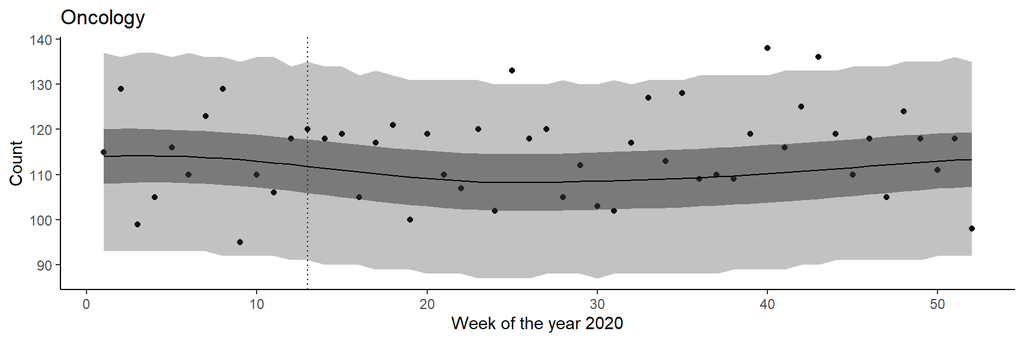

```r
attels_C00C97_weeks <- ggplot(C00C97_2020,aes(x=WOY,y=Malignant_neoplasms))+
  geom_vline(xintercept=13,lty=3)+
  theme_classic()+
  geom_point()+
  geom_ribbon(data=C00C97_2020,aes(x=WOY,ymin=`2.5%`,ymax=`97.5%`),alpha=.3)+
  geom_ribbon(data=C00C97_2020,aes(x=WOY,ymin=min_C00C97_cc_c,ymax=max_C00C97_cc_c),alpha=.5)+
  geom_line(data=C00C97_2020,aes(x=WOY,y=fit_C00C97_cc_c))+
  xlab("Week of the year 2020")+
  ylab("Count")+
  ggtitle("Oncology")
attels_C00C97_weeks
```

# E10_E14 - diabetes mellitus

Fitting models

```r
E10E14_tp_c=gam(Diabetes_mellitus ~ fgads + s(WOY,k=52,bs="tp")+offset(log(pop)),
               data=macibam,family=poisson(link="log"),method="REML")
E10E14_tp_fx=gam(Diabetes_mellitus ~ fgads + s(WOY,k=52,fx=TRUE,bs="tp")+offset(log(pop)),
                data=macibam,family=poisson(link="log"),method="REML")
E10E14_cr_c=gam(Diabetes_mellitus ~ fgads + s(WOY,k=51,bs="cr")+offset(log(pop)),
               data=macibam,family=poisson(link="log"),method="REML")
E10E14_cr_fx=gam(Diabetes_mellitus ~ fgads + s(WOY,k=52,fx=TRUE,bs="cr")+offset(log(pop)),
                data=macibam,family=poisson(link="log"),method="REML")
E10E14_cc_c=gam(Diabetes_mellitus ~ fgads + s(WOY,k=52,bs="cc")+offset(log(pop)),
               data=macibam,family=poisson(link="log"),method="REML")
E10E14_cc_fx=gam(Diabetes_mellitus ~ fgads + s(WOY,k=52,fx=TRUE,bs="cc")+offset(log(pop)),
                data=macibam,family=poisson(link="log"),method="REML")
```

Comparing fitted models. The best model is E10E14_cc_c - cyclic cubic splines with non-fixed effect of the week

```r
AICc(E10E14_tp_c,E10E14_tp_fx,E10E14_cr_c,E10E14_cr_fx,E10E14_cc_c,E10E14_cc_fx)
```

```
##                     df     AICc
## E10E14_tp_c   8.710508 1432.498
## E10E14_tp_fx 57.000000 1497.650
## E10E14_cr_c   8.710384 1432.497
## E10E14_cr_fx 57.000000 1497.650
## E10E14_cc_c   8.817548 1432.079
## E10E14_cc_fx 56.000000 1494.674
```

Model summary

```r
summary(E10E14_cc_c)
```

```
##
## Family: poisson
## Link function: log
##
## Formula:
## Diabetes_mellitus ~ fgads + s(WOY, k = 52, bs = "cc") + offset(log(pop))
##
## Parametric coefficients:
##              Estimate Std. Error  z value Pr(>|z|)
## (Intercept) -12.29428    0.04613 -266.524  < 2e-16 ***
## fgads2016     0.15922    0.06292    2.530 0.011393 *
## fgads2017     0.21841    0.06221    3.511 0.000446 ***
## fgads2018     0.23998    0.06202    3.870 0.000109 ***
## fgads2019     0.35266    0.06061    5.819 5.93e-09 ***
## fgads2020     0.25542    0.09508    2.686 0.007222 **
## ---
## Signif. codes:  0 '***' 0.001 '**' 0.01 '*' 0.05 '.' 0.1 ' ' 1
##
## Approximate significance of smooth terms:
##         edf Ref.df Chi.sq p-value
## s(WOY) 2.15     50  8.656 0.00646 **
## ---
## Signif. codes:  0 '***' 0.001 '**' 0.01 '*' 0.05 '.' 0.1 ' ' 1
##
## R-sq.(adj) =  0.111   Deviance explained = 15.4%
## -REML =  722.7  Scale est. = 1         n = 273
```

Relative risks for years

```r
apk_E10E14_cc_c=summary(E10E14_cc_c)
RR_E10E14=round(exp(apk_E10E14_cc_c$p.coeff),3)
RRmin_E10E14=round(exp(apk_E10E14_cc_c$p.coeff-1.96*apk_E10E14_cc_c$se[1:6]),3)
RRmax_E10E14=round(exp(apk_E10E14_cc_c$p.coeff+1.96*apk_E10E14_cc_c$se[1:6]),3)
rbind(RR_E10E14,RRmin_E10E14,RRmax_E10E14)
```

```
##              (Intercept) fgads2016 fgads2017 fgads2018 fgads2019 fgads2020
## RR_E10E14              0     1.173     1.244     1.271     1.423     1.291
## RRmin_E10E14           0     1.037     1.101     1.126     1.263     1.072
## RRmax_E10E14           0     1.327     1.405     1.436     1.602     1.555
```

### Confidence intervals

Prediction of the numbers of cases with 95% confidence intervals.

```r
pred_E10E14_cc_c=as.data.frame(predict(E10E14_cc_c,newdata = dati,se=TRUE,type="response"))
pred_E10E14_cc_c$min_E10E14_cc_c=pred_E10E14_cc_c$fit-1.96*pred_E10E14_cc_c$se.fit
pred_E10E14_cc_c$max_E10E14_cc_c=pred_E10E14_cc_c$fit+1.96*pred_E10E14_cc_c$se.fit
colnames(pred_E10E14_cc_c)[1]="fit_E10E14_cc_c"
pred_E10E14_cc_c=pred_E10E14_cc_c[,c(1,3,4)]

E10E14ie=cbind(dati,pred_E10E14_cc_c)
```

### Prediction intervals

Prediction intervals cannot be obtained with function predict as in lm. They have to be simulated from the posterior.

```r
# extract the parameter estimates and their covariance matrix
beta=coef(E10E14_cc_c)
V=vcov(E10E14_cc_c)

# Simulate number of parameter vectors by Cholesky factorisation of the covariance matrix
num_beta_vecs <- 10000
Cv <- chol(V)
set.seed(1)
nus <- rnorm(num_beta_vecs * length(beta))
beta_sims <- beta + t(Cv) %*% matrix(nus, nrow = length(beta), ncol = num_beta_vecs)

# use data for predictions
sim_dat2=dati

# calculate linear predictors
covar_sim <- predict(E10E14_cc_c, newdata = sim_dat2, type = "lpmatrix")
linpred_sim <- covar_sim %*% beta_sims

# inverse link function
exp_val_sim <- exp(linpred_sim)

# matrix for predictions
exp_val_sim2 <- matrix(NA,nrow=nrow(exp_val_sim),ncol=ncol(exp_val_sim))

# as offset was used, need to account for population size
for (i in 1:ncol(exp_val_sim)){
  for (j in 1:nrow(exp_val_sim)){
    exp_val_sim2[j,i]=exp_val_sim[j,i]*dati$pop[j]
  }
}

# posterior draws from Poisson family
y_sim <- matrix(rpois(n = prod(dim(exp_val_sim2)),
                      lambda = exp_val_sim2),
                nrow = nrow(exp_val_sim2),
                ncol = ncol(exp_val_sim2))

# reduction to prediction interval
pred_int_sim <- apply(y_sim, 1, quantile, prob = c(.025, 0.975))

# transpose matrix
predint_E10E14_cc_c=t(pred_int_sim)

# combine with data and confidence intervals
kopejais_E10E14_cc_c=cbind(dati,pred_E10E14_cc_c,predint_E10E14_cc_c)
```

### Results

Preparation of table with observed, model predicted, difference and excess values

```r
# Extract values from 2020
E10E14_2020=kopejais_E10E14_cc_c %>%
  filter(fgads==2020)

# pick necessary columns
E10E14_2020_csv=E10E14_2020[,c("gads","WOY","Diabetes_mellitus","fit_E10E14_cc_c","2.5%","97.5%")]

E10E14_2020_csv=E10E14_2020_csv %>%
  mutate(Diabetes_observed=Diabetes_mellitus,
         Diabetes_fitted=round(fit_E10E14_cc_c,0),
         Diabetes_PImin=round(`2.5%`,0),
         Diabetes_PImax=round(`97.5%`,0)) %>%
  group_by(WOY,Diabetes_observed,Diabetes_fitted,Diabetes_PImin,Diabetes_PImax) %>%
  summarize(Diabetes_diff=round(Diabetes_mellitus-Diabetes_fitted,0),
            Diabetes_diff_PImin=round(Diabetes_mellitus-Diabetes_PImax,0),
            Diabetes_diff_PImax=round(Diabetes_mellitus-Diabetes_PImin,0),
            Diabetes_excess=ifelse(round(Diabetes_mellitus-Diabetes_fitted,0)>0,
                                   round(Diabetes_mellitus-Diabetes_fitted,0),0),
            Diabetes_excess_max=ifelse(round(Diabetes_mellitus-Diabetes_PImin,0)>0,
                                       round(Diabetes_mellitus-Diabetes_PImin,0),0),
            Diabetes_excess_min=ifelse(round(Diabetes_mellitus-Diabetes_PImax,0)>0,
                                       round(Diabetes_mellitus-Diabetes_PImax,0),0)) %>%
ungroup()
write_excel_csv2(E10E14_2020_csv,"./outputs/table_Diabetes.csv") # write resulting table to file
```

### Figures

Observed and model predicted values in 2020

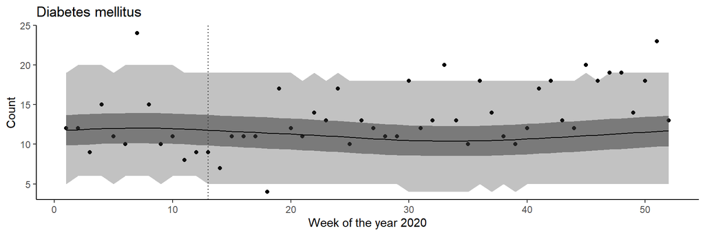

```r
attels_E10E14_weeks <- ggplot(E10E14_2020,aes(x=WOY,y=Diabetes_mellitus))+
  geom_vline(xintercept=13,lty=3)+
  theme_classic()+
  geom_point()+
  geom_ribbon(data=E10E14_2020,aes(x=WOY,ymin=`2.5%`,ymax=`97.5%`),alpha=.3)+
  geom_ribbon(data=E10E14_2020,aes(x=WOY,ymin=min_E10E14_cc_c,ymax=max_E10E14_cc_c),alpha=.5)+
  geom_line(data=E10E14_2020,aes(x=WOY,y=fit_E10E14_cc_c))+
  xlab("Week of the year 2020")+
  ylab("Count")+
  ggtitle("Diabetes mellitus")
attels_E10E14_weeks
```

# J42_J47 - chronic lower respiratory diseases

Fitting models

```r
J42J47_tp_c=gam(CLRd ~ fgads + s(WOY,k=52,bs="tp")+offset(log(pop)),
               data=macibam,family=poisson(link="log"),method="REML")
J42J47_tp_fx=gam(CLRd ~ fgads + s(WOY,k=52,fx=TRUE,bs="tp")+offset(log(pop)),
                data=macibam,family=poisson(link="log"),method="REML")
J42J47_cr_c=gam(CLRd ~ fgads + s(WOY,k=51,bs="cr")+offset(log(pop)),
               data=macibam,family=poisson(link="log"),method="REML")
J42J47_cr_fx=gam(CLRd ~ fgads + s(WOY,k=52,fx=TRUE,bs="cr")+offset(log(pop)),
                data=macibam,family=poisson(link="log"),method="REML")
J42J47_cc_c=gam(CLRd ~ fgads + s(WOY,k=52,bs="cc")+offset(log(pop)),
               data=macibam,family=poisson(link="log"),method="REML")
J42J47_cc_fx=gam(CLRd ~ fgads + s(WOY,k=52,fx=TRUE,bs="cc")+offset(log(pop)),
                data=macibam,family=poisson(link="log"),method="REML")
```

Comparing fitted models. The best model is J42J47_tp_c - thin plate splines with non-fixed effect of the week

```r
AICc(J42J47_tp_c,J42J47_tp_fx,J42J47_cr_c,J42J47_cr_fx,J42J47_cc_c,J42J47_cc_fx)
```

```
##                    df     AICc
## J42J47_tp_c  11.40307 1295.859
## J42J47_tp_fx 57.00000 1370.122
## J42J47_cr_c  11.49322 1296.058
## J42J47_cr_fx 57.00000 1370.122
## J42J47_cc_c  10.60074 1297.011
## J42J47_cc_fx 56.00000 1367.054
```

Model summary

```r
summary(J42J47_tp_c)
```

```
##
## Family: poisson
## Link function: log
##
## Formula:
## CLRd ~ fgads + s(WOY, k = 52, bs = "tp") + offset(log(pop))
##
## Parametric coefficients:
##              Estimate Std. Error  z value Pr(>|z|)
## (Intercept) -12.78590    0.05889 -217.131   <2e-16 ***
## fgads2016     0.18929    0.07969    2.375   0.0175 *
## fgads2017     0.17217    0.08017    2.148   0.0318 *
## fgads2018     0.18877    0.08001    2.359   0.0183 *
## fgads2019     0.01563    0.08355    0.187   0.8516
## fgads2020    -0.07632    0.13026   -0.586   0.5579
## ---
## Signif. codes:  0 '***' 0.001 '**' 0.01 '*' 0.05 '.' 0.1 ' ' 1
##
## Approximate significance of smooth terms:
##          edf Ref.df Chi.sq p-value
## s(WOY) 4.599  5.747  52.03  <2e-16 ***
## ---
## Signif. codes:  0 '***' 0.001 '**' 0.01 '*' 0.05 '.' 0.1 ' ' 1
##
## R-sq.(adj) =  0.163   Deviance explained = 18.2%
## -REML = 655.91  Scale est. = 1         n = 273
```

Relative risks for years

```r
apk_J42J47_tp_c=summary(J42J47_tp_c)
RR_J42J47=round(exp(apk_J42J47_tp_c$p.coeff),3)
RRmin_J42J47=round(exp(apk_J42J47_tp_c$p.coeff-1.96*apk_J42J47_tp_c$se[1:6]),3)
RRmax_J42J47=round(exp(apk_J42J47_tp_c$p.coeff+1.96*apk_J42J47_tp_c$se[1:6]),3)
rbind(RR_J42J47,RRmin_J42J47,RRmax_J42J47)
```

```
##              (Intercept) fgads2016 fgads2017 fgads2018 fgads2019 fgads2020
## RR_J42J47              0     1.208     1.188     1.208     1.016     0.927
## RRmin_J42J47           0     1.034     1.015     1.032     0.862     0.718
## RRmax_J42J47           0     1.413     1.390     1.413     1.197     1.196
```

### Confidence intervals

Prediction of the numbers of cases with 95% confidence intervals.

```r
pred_J42J47_tp_c=as.data.frame(predict(J42J47_tp_c,newdata = dati,se=TRUE,type="response"))
pred_J42J47_tp_c$min_J42J47_tp_c=pred_J42J47_tp_c$fit-1.96*pred_J42J47_tp_c$se.fit
pred_J42J47_tp_c$max_J42J47_tp_c=pred_J42J47_tp_c$fit+1.96*pred_J42J47_tp_c$se.fit
colnames(pred_J42J47_tp_c)[1]="fit_J42J47_tp_c"
pred_J42J47_tp_c=pred_J42J47_tp_c[,c(1,3,4)]

J42J47ie=cbind(dati,pred_J42J47_tp_c)
```

### Prediction intervals

Prediction intervals cannot be obtained with function predict as in lm. They have to be simulated from the posterior.

```r
# extract the parameter estimates and their covariance matrix
beta=coef(J42J47_tp_c)
V=vcov(J42J47_tp_c)

# Simulate number of parameter vectors by Cholesky factorisation of the covariance matrix
num_beta_vecs <- 10000
Cv <- chol(V)
set.seed(1)
nus <- rnorm(num_beta_vecs * length(beta))
beta_sims <- beta + t(Cv) %*% matrix(nus, nrow = length(beta), ncol = num_beta_vecs)

# use data for predictions
sim_dat2=dati

# calculate linear predictors
covar_sim <- predict(J42J47_tp_c, newdata = sim_dat2, type = "lpmatrix")
linpred_sim <- covar_sim %*% beta_sims


# inverse link function
exp_val_sim <- exp(linpred_sim)

# matrix for predictions
exp_val_sim2 <- matrix(NA,nrow=nrow(exp_val_sim),ncol=ncol(exp_val_sim))

# as offset was used, need to account for population size
for (i in 1:ncol(exp_val_sim)){
  for (j in 1:nrow(exp_val_sim)){
    exp_val_sim2[j,i]=exp_val_sim[j,i]*dati$pop[j]
  }
}

# posterior draws from Poisson family
y_sim <- matrix(rpois(n = prod(dim(exp_val_sim2)),
                      lambda = exp_val_sim2),
                nrow = nrow(exp_val_sim2),
                ncol = ncol(exp_val_sim2))

# reduction to prediction interval
pred_int_sim <- apply(y_sim, 1, quantile, prob = c(.025, 0.975))

# transpose matrix
predint_J42J47_tp_c=t(pred_int_sim)


# combine with data and confidence intervals
kopejais_J42J47_tp_c=cbind(dati,pred_J42J47_tp_c,predint_J42J47_tp_c)
```

### Results

Preparation of table with observed, model predicted, difference and excess values

```r
# Extract values from 2020
J42J47_2020=kopejais_J42J47_tp_c %>%
  filter(fgads==2020)

# pick necessary columns
J42J47_2020_csv=J42J47_2020[,c("gads","WOY","CLRd","fit_J42J47_tp_c","2.5%","97.5%")]

J42J47_2020_csv=J42J47_2020_csv %>%
  mutate(CLRd_observed=CLRd,
         CLRd_fitted=round(fit_J42J47_tp_c,0),
         CLRd_PImin=round(`2.5%`,0),
         CLRd_PImax=round(`97.5%`,0)) %>%
  group_by(WOY,CLRd_observed,CLRd_fitted,CLRd_PImin,CLRd_PImax) %>%
  summarize(CLRd_diff=round(CLRd_observed-CLRd_fitted,0),
            CLRd_diff_PImin=round(CLRd_observed-CLRd_PImax,0),
            CLRd_diff_PImax=round(CLRd_observed-CLRd_PImin,0),
            CLRd_excess=ifelse(round(CLRd_observed-CLRd_fitted,0)>0,
                                   round(CLRd_observed-CLRd_fitted,0),0),
            CLRd_excess_max=ifelse(round(CLRd_observed-CLRd_PImin,0)>0,
                                       round(CLRd_observed-CLRd_PImin,0),0),
            CLRd_excess_min=ifelse(round(CLRd_observed-CLRd_PImax,0)>0,
                                       round(CLRd_observed-CLRd_PImax,0),0)) %>%
ungroup()
write_excel_csv2(J42J47_2020_csv,"./outputs/table_CLRd.csv") # write resulting table to file
```

### Figures

Observed and model predicted values in 2020

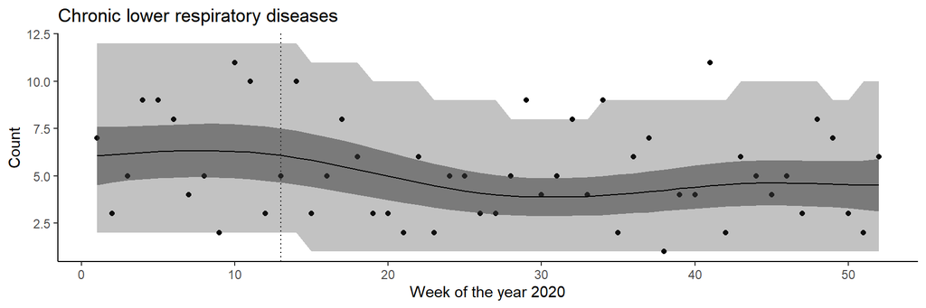

```r
attels_J42J47_weeks <- ggplot(J42J47_2020,aes(x=WOY,y=CLRd))+
  geom_vline(xintercept=13,lty=3)+
  theme_classic()+
  geom_point()+
  geom_ribbon(data=J42J47_2020,aes(x=WOY,ymin=`2.5%`,ymax=`97.5%`),alpha=.3)+
  geom_ribbon(data=J42J47_2020,aes(x=WOY,ymin=min_J42J47_tp_c,ymax=max_J42J47_tp_c),alpha=.5)+
  geom_line(data=J42J47_2020,aes(x=WOY,y=fit_J42J47_tp_c))+
  xlab("Week of the year 2020")+
  ylab("Count")+
  ggtitle("Chronic lower respiratory diseases")
attels_J42J47_weeks
```

# Supplementary table

```r
bt=merge(total_2020_csv,I00I99_2020_csv,by=c("WOY"))
bt=merge(bt,C00C97_2020_csv,by=c("WOY"))
bt=merge(bt,E10E14_2020_csv,by=c("WOY"))
beigu_tabula=merge(bt,J42J47_2020_csv,by=c("WOY"))
write_excel_csv2(beigu_tabula,"./outputs/tabula_apvienots.csv")
```